# Aplicações de MWU (cont.)

MAC5005 - Fundamentos Matemáticos do Aprendizado Sequencial e Online

Victor S. Portella

IME-USP

2026-03-16

## Relembrando - Predição com Ajuda de Experts Convexificado

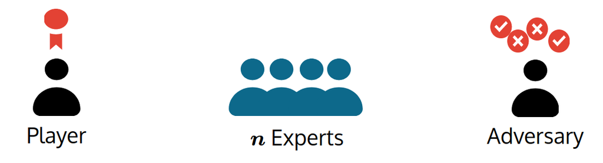

- O **Jogador/Algoritmo** escolhe uma distribuição $p_t \in \Delta_d$ sobre os experts, onde
  $$\Delta_d = \Big \{ p \in [0,1]^d \; \colon\; \sum_{i=1}^d p_i = 1 \Big \}$$
- O **Adversário** escolhe custos<sup>1</sup> $\ell_t \in [-1,1]^d$ para os experts
- O **Jogador/Algoritmo** sofre o custo esperado $\ell_t^\T p_t$
[^1]: As provas que fizemos com $\ell_t \in [0,1]^d$ valem para $\ell_t \in [-1,1]^d$

## Relembrando - Regret e MWU

**Regret:** comparar custo com o do melhor expert do jogo.
$$\Regret(T) = \sum_{t=1}^T \ell_t^\T p_t - \min_{i \in [d]} \sum_{t = 1}^T \ell_t(i)$$

**Objetivo:** garantir $\Regret(T)/T \to 0$.
$$\frac{\Regret(T)}{T} \longrightarrow 0 \quad \text{quando} \quad T \to \infty.$$

**MWU$(T, \eta)$**

Defina $w_1 := \ones$ Para $t = 1, \dotsc, T$:

- **Jogador** revela $p_t = \frac{w_t}{\lVert w_t\rVert_1} \in \Delta_d$
- **Adversário** revela os custos $\ell_t \in [0,1]^d$ e **Jogador** atualiza os pesos $w_{t+1}$:
  $$w_{t+1}(i) := w_t(i) \cdot \exp(-\eta \ell_t(i)) \quad \text{para todo}~i \in [d]$$

## Relembrando - Regret de MWU

Para $\eta > 0$, o algoritmo MWU($T, \eta$) garante
$$\Regret(T) \leq \frac{\ln d}{\eta} + \frac{\eta T}{2}$$
Em particular, se $\eta = \sqrt{2 \ln d/T}$
$$\Regret(T) \leq \sqrt{2 T \ln d}.$$

## Relembrando - Jogos de Soma Zero

- **Jogador linha** seleciona uma **distribuição** $q \in \Delta_m$ sobre as linhas
- **Jogador coluna** seleciona uma **distribuição** $p \in \Delta_n$ sobre as colunas
- A recompensa (esperada) do **jogador linha** é:

$$\sum_{i = 1}^m \sum_{j = 1}^n A(i,j) q_i p_j = q^\T A p$$

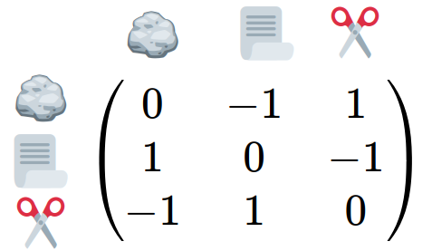

## Relembrando - Equilíbrio Aproximado

- **Jogador coluna** joga sua estratégia atual $p_t$ (começa com $p_1 = \frac{1}{n} \mathbb{1}$)
- **Jogador linha** escolhe $q_t = e_j$ onde a linha $j$ maximiza $e_j^\T A p_t$
- **Jogador coluna** atualiza sua estratégia com MWU

Defina $\displaystyle \bar{p} = \frac{1}{T} \sum_{t = 1}^T p_t$ e $\displaystyle \bar{q} = \frac{1}{T} \sum_{t = 1}^T q_t$. Então, para todo $q \in \Delta_m, p \in \Delta_n$,

$$\begin{aligned}
q^\T A \bar{p} &\leq \frac{\Regret(T)}{T} + \max_q \min_p q^\T A p
\quad \text{e} \\
\bar{q}^\T A p &\geq - \frac{\Regret(T)}{T} + \min_p \max_q q^\T A p
\end{aligned}
% \displaystyle \text{OPT} - \frac{\text{Regret}(T)}{T} \leq \bar{q}^\T A \bar{p} \leq \text{OPT} + \frac{\text{Regret}(T)}{T}$$
Em particular, $\max_{p} \min_{q } q^\T A p = \min_{q} \max_{p} q^\T A p$ e, se $T > 2 \ln m/\eps^2$, $\Regret(T)/T \leq \eps$.

## Relembrando - Aprendizado Fraco e Boosting

Uma classe de hipóteses $\cH$ é **fracamente PAC-aprendível** (*weakly PAC learnable*) se existe um algoritmo $A \colon (\cX \times \cY)^* \to \cB$ (com $\cB \subseteq \cY^{\cX}$) e uma constante **$\gamma > 0$** tais que

- Para todo $\delta$ > 0,
- Para toda distribuição $\cD$ sobre $\cX \times \cY$ realizada por $\cH$,
- Existe $M(\delta) > 0$ tal que
- Se $m > M(\delta)$ e $S \sim \cD^m$

então
$$\prob \Big( L_{\cD}(A(S)) \leq \frac{1}{2} - \gamma \Big) > 1 - \delta.$$

Chamamos $A$ de um **weak learner** e $\cB$ de conjunto de **classificadores base**.

**A principal diferença:**

- **PAC-aprendivel**: erro de generalizacão arbitrariamente pequeno ($\leq \eps$)
- **Fracamente PAC-aprendivel**: erro de generalizacão um pouco ($\gamma$) melhor que jogar uma moeda

## Relembrando - O Oráculo *Weak Learner*

Vamos assumir que temos acesso a um **oráculo** (uma sub-rotina) que resolve o problema do aprendizado fraco no conjunto de treino.

A função $\mathrm{WL}$ recebe

- **conjunto de treino** $S = ((x_1, y_1), \dotsc, (x_m, y_m))$;
- uma **distribuição** $p \in \Delta_m$ sobre os exemplos de $S$;

$$L_{p}(h) = \sum_{i=1}^m p_t(i) \ones[h_t(x_i) \neq y_i] \leq \frac{1}{2} - \gamma$$

## Relembrando - Boosting básico com MWU

**IMPORTANTE**: Para simplificar, vamos assumir $\cY =\{-1,1\}$ ao inés de $\cY = \{0,1\}$

- **Algoritmo** passa a distribuição atual $p_t \in \Delta_m$ (começa com $p_1 = \frac{1}{m} \mathbb{1}$)
- **Weak Learner** escolhe uma hipótese $h_t$ que performa bem nos dados pesados por $p_t$
- **Algoritmo** atualiza a distribuição sobre os exemplos com MWU:
  $$p_{t+1}(i) \propto p_t(i) \exp(-\eta \ell_t(i))
  \quad \text{onde} \quad
  \ell_t(i) = h_t(x_i) y_i$$
  **Saída:** A hipótese final $h_{S}(x)$ é dada pelo **voto da maioria**:
  $$h_{S}(x) := \mathrm{majority}\big(h_1(x), h_2(x), \dots, h_T(x)\big)$$

## Relembrando - Exemplo em Figura

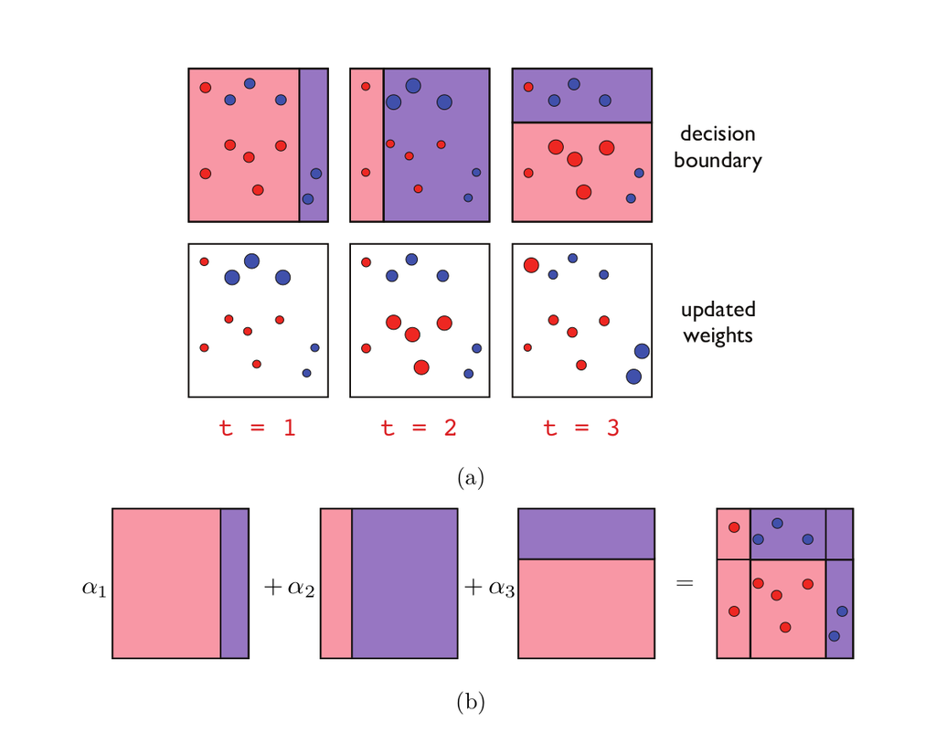

Fig. 7.2 do MRT

## Relembrando - Análise de Boosting via MWU

$$\Regret(T) \leq \frac{\ln d}{\eta} + \frac{\eta T}{2}$$

Se $h_S$ é a hipótese gerada pelo Boosting básico com $\eta = \gamma$, então
$$T > \frac{\ln m}{\gamma^2} \implies
L_{S}(h_{S}) =
\frac{1}{m}\sum_{i = 1}^m \ones[h_{S}(x_i)\neq y_i] = 0.$$

**Pergunta**: Se $T \leq \ln m/\gamma^2$, não temos nenhuma garantia em $L_S(h_S)$?

# Melhorando a Análise de Boosting e o Algoritmo AdaBoost

## Análise Melhorada de MWU

Lembre do potencial no MWU
$$\Phi_t := \log \Big( \sum_{i = 1}^d w_{t,i} \Big)$$

Para $\ell_t \in [-1,1]$ e qualquer $E \subseteq [d]$
$$\begin{aligned}
\Phi_{t+1} - \Phi_{t} &= \log \Big( \sum_{i = 1}^d p_{t,i} \exp(- \eta \ell_{t,i})\Big)
\leq - \eta \ell_t^\T p_t + \frac{\eta^2}{2},
\\
\Phi_{T+1} &\geq \ln |E|- \eta \max_{i \in E} \sum_{t = 1}^T \ell_t(i)
\quad \text{e} \quad \Phi_1 = \ln d.
\end{aligned}$$
Em particular,
$$\sum_{t = 1}^T \ell_t^\T p_t - \max_{i \in [E]} \sum_{t = 1}^T \ell_t(i) \leq \frac{\ln(d/|E|)}{\eta} + \frac{\eta T}{2}$$

## Análise Melhorada de Boosting Básico

Se $h_S$ é a hipótese gerada pelo Boosting básico com $\eta = \gamma$, então
$$L_{S}(h_{S}) \leq \exp(- T \gamma^2)$$

**Pergunta**: Temos como fazer boosting *sem saber* o valor de $\gamma$?

## O Algoritmo AdaBoost

**Inicialização:** Pesos uniformes $p_1(i) = \frac{1}{m}$ para $i \in [m]$.

Para cada rodada $t = 1, \dotsc, T$:

1. O **Algoritmo** obtém a hipótese $h_t = \mathrm{WL}(p_t, S)$
2. Define-se a importância da hipótese (tamanho do passo):
   $$\eta_t := \frac{1}{2} \log\Big(\frac{1 - \eps_t}{\eps_t}\Big) \quad \text{onde}~ \eps_t := L_S(h_t)$$
3. **Algoritmo** calcula $p_{t+1}$ via MWU com passo $\eta_{t}$ e $\ell_{t,i} = y_i h_t(x_i)$ na rodada $t$

**Saída:** **Voto da maioria ponderado** pelo peso de cada hipótese:
$$h_S(x) = \mathrm{sign}\Big(\sum_{t=1}^T \eta_t h_t(x)\Big)$$

## Análise de AdaBoost

No caso de AdaBoost, lembrando $\eps_t = L_S(h_t)$, temos
$$\begin{aligned}
L_S(h_S)
\leq \exp \Big( -2 \sum_{t = 1}^T \Big( \frac{1}{2} - \eps_t\Big)^2\Big)
\leq \exp\big( - 2 \gamma^2 T \big).
\end{aligned}$$

## Extra - Dimensão VC das Hipósteses de Boosting

Boosting devolve uma hipótese com $L_S(h_S) = 0$. **Mas será que generaliza?**

Defina $d := \VC(\cB)$ e
$$\cH_T := \Bigg\{ \mathrm{sign}\Big(\sum_{t = 1}^T \eta_t h_t\Big) \;\colon\; \eta_t \geq 0, h_t \in \cB~\text{para todo}~t \in [T]\Bigg\}.$$
Então
$$\VC(\cH_T) \leq 2(d+1)(T+1) \lg((T + 1)e)$$

## Extra - Dimensão VC não é o Fim da História

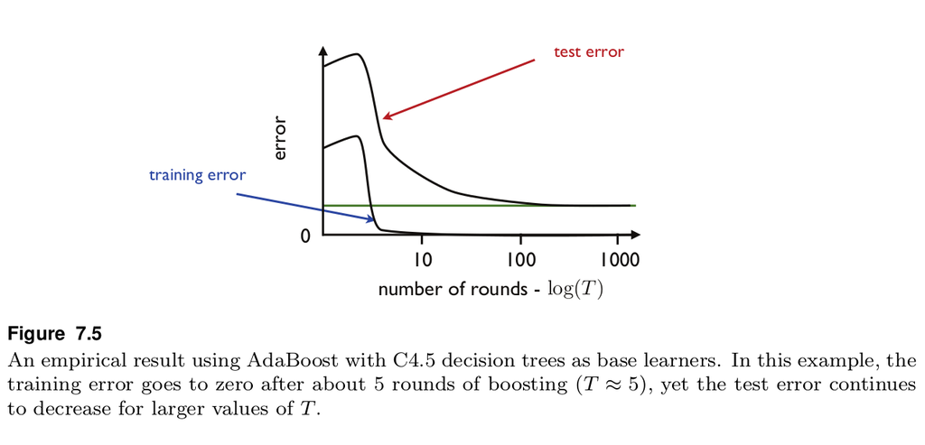

Figura do MRT

# Multi-Armed Bandit

## Bandits: Experts com Menos Informação

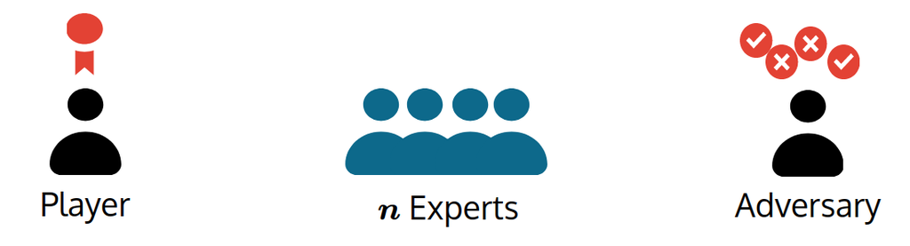

No problema dos experts: **Jogador** vê os custos $\ell_t$ de **todos** os experts

Se os experts são **ações na bolsa**, isso faz sentido

Se os experts são **possíveis tratamentos médicos**, faz menos sentido

**Multi-armed Bandits**: Similar ao problema dos experts, mas na rodada $t$

**Jogador** escolhe $i_t \in [d]$ (de forma aleatorizada)]

**Adversário** revela **somente** $\ell_t(i_t) \in [d]$ para o **Jogador**

## Multi-Armed Bandit

- O **Jogador** escolhe uma distribuição $p_t \in \Delta_d$ sobre os experts, onde
  $$\Delta_d = \Big \{ p \in [0,1]^d \; \colon\; \sum_{i=1}^d p_i = 1 \Big \}$$
- O **Adversário** escolhe custos $\ell_t \in [-1,1]^d$ para os experts
- O **Jogador** escolhe $A_t \in [d]$ com
  $$\prob[A_t = i] = p_t(i) \quad \text{para todo}~i \in [d]$$
- O **Jogador** sofre o custo $\ell_t(A_t)$

Queremos agora controlar o **pseudo-regret**: (discussão em sala)
$$\PRegret(T)
= \expect\Big[\sum_{t = 1}^T \ell_t(A_t) \Big] - \min_{i \in [d]} \expect\Big[\sum_{t = 1}^T \ell_t(i)\Big]$$

## Bandits via MWU - Algoritmo EXP3

**Ideia**: Na rodada $t$, criar um estimador $\tilde{\ell}_t$ dos custos e usar MWU. Esse algoritmo é conhecido como **EXP3**.

**Inicialização:** Pesos uniformes $p_1(i) = \frac{1}{d}$ para $i \in [d]$.

Para cada rodada $t = 1, \dotsc, T$:

- **Sorteamos** $A_t \sim p_t$ e sofremos o custo $\ell_t(A_t)$
- **Definimos um estimador $\tilde{\ell}_t \in [0,1]^d$**
  $$\tilde{\ell}_t(i) = \ones[A_t = i] \frac{\ell_t(i)}{p_t(i)} \qquad \text{para todo}~i \in [d].$$
- Atualizamos os pesos $p_{t+1} \in \Delta_{d}$ usando $\tilde{\ell}_t$ via **MWU($\eta, T$)**.

## Re-Revisitrando a Análise de MWU

Para $\ell_t \in [-1,1]$ e qualquer $E \subseteq [d]$
$$\begin{aligned}
\Phi_{t+1} - \Phi_{t} &= \log \Big( \sum_{i = 1}^d p_{t,i} \exp(- \eta \ell_{t,i})\Big)
\leq - \eta \ell_t^\T p_t + \frac{\eta^2}{2} \sum_{i = 1}^d\ell_t(i)^2 p_t(i),
\\
\Phi_{T+1} &\geq \ln |E|- \eta \max_{i \in E} \sum_{t = 1}^T \ell_t(i)
\quad \text{e} \quad \Phi_1 = \ln d.
\end{aligned}$$
Em particular, para EXP3 temos, para todo $i \in [d]$
$$\expect \Big[ \sum_{t = 1}^T \tilde{\ell}_t^\T p_t - \sum_{t = 1}^T \tilde{\ell}_t(i) \Big] \leq \frac{\ln d}{\eta} + \frac{\eta}{2} \sum_{t = 1}^T \expect\Big[\sum_{i = 1}^d p_{t}(i)\tilde{\ell}_t(i)^2\Big].$$

## Estimador não Viesado de $\ell_t$

Se
$$\tilde{\ell}_t(i) = \ones[A_t = i] \frac{\ell_t(i)}{\tilde{p}_t(i)} \qquad \text{para todo}~i \in [d].$$
então
$$\expect[\tilde{\ell}_t] = \ell_t \qquad e \qquad \expect\Big[\sum_{i = 1}^d p_{t}(i)\tilde{\ell}_t(i)^2\Big] \leq d.$$

Temos que
$$\PRegret(T) \leq \frac{\ln d}{\eta} + \frac{\eta T d}{2}.$$
Em particular, se $\eta = \sqrt{2 \ln d/T d}$, entãp $\PRegret(T) \leq \sqrt{2 T d \ln d}$.